# Reproducible Research P1

Mauricio Rueda

19 de abril de 2019

### Settings and libraries

```r
Sys.setlocale("LC_ALL","English")
```

```
## [1] "LC_COLLATE=English_United States.1252;LC_CTYPE=English_United States.1252;LC_MONETARY=English_United States.1252;LC_NUMERIC=C;LC_TIME=English_United States.1252"
```

```r
setwd("~/GitHub/RepData_PeerAssessment1")
library(lattice)
library(ggplot2)
```

### tasks list

1. Load the data (i.e. read.csv()read.csv())

```r
datos <- read.csv("activity.csv",stringsAsFactors = FALSE)
```

1.1. Process/transform the data (if necessary) into a format suitable for your analysis

```r
datos$date <- as.Date(datos$date)

datos_hist <- datos[!is.na(datos$steps),]
```

2.Histogram of the total number of steps taken each day

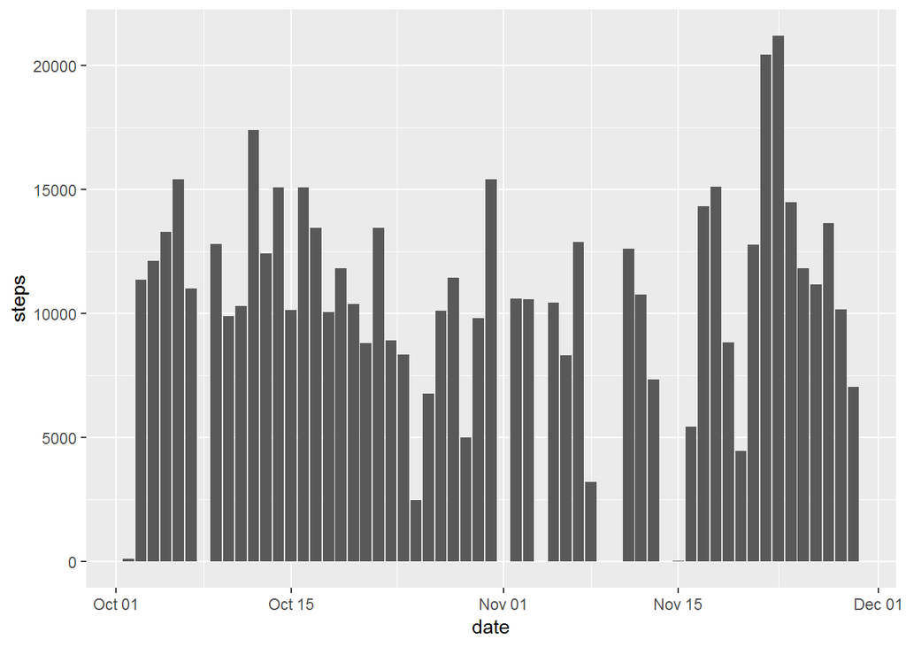

```r
tabla.sum <- aggregate(datos_hist[,1], list(datos_hist$date), sum)
colnames(tabla.sum) <- c("date","steps")
ggplot(tabla.sum,aes(x=date,y=steps))+geom_bar(stat='identity')
```

3.Mean and median number of steps taken each day

```r
tabla.mean <- aggregate(datos_hist[,1], list(datos_hist$date), mean)

colnames(tabla.mean) <- c("date","mean")

print(tabla.mean,type="html")
```

```
##          date       mean
## 1  2012-10-02  0.4375000
## 2  2012-10-03 39.4166667
## 3  2012-10-04 42.0694444
## 4  2012-10-05 46.1597222
## 5  2012-10-06 53.5416667
## 6  2012-10-07 38.2465278
## 7  2012-10-09 44.4826389
## 8  2012-10-10 34.3750000
## 9  2012-10-11 35.7777778
## 10 2012-10-12 60.3541667
## 11 2012-10-13 43.1458333
## 12 2012-10-14 52.4236111
## 13 2012-10-15 35.2048611
## 14 2012-10-16 52.3750000
```

[output cut: 39 more lines]

```r
tabla.median <- aggregate(datos_hist[,1], list(datos_hist$date), median)

colnames(tabla.median) <- c("date","median")

print(tabla.median,type="html")
```

```
##          date median
## 1  2012-10-02      0
## 2  2012-10-03      0
## 3  2012-10-04      0
## 4  2012-10-05      0
## 5  2012-10-06      0
## 6  2012-10-07      0
## 7  2012-10-09      0
## 8  2012-10-10      0
## 9  2012-10-11      0
## 10 2012-10-12      0
## 11 2012-10-13      0
## 12 2012-10-14      0
## 13 2012-10-15      0
## 14 2012-10-16      0
```

[output cut: 39 more lines]

4.Time series plot of the average number of steps taken

```r
tabla.five <- aggregate(datos_hist[,1], list(datos_hist$interval), mean)

colnames(tabla.five) <- c("interval","mean")
```

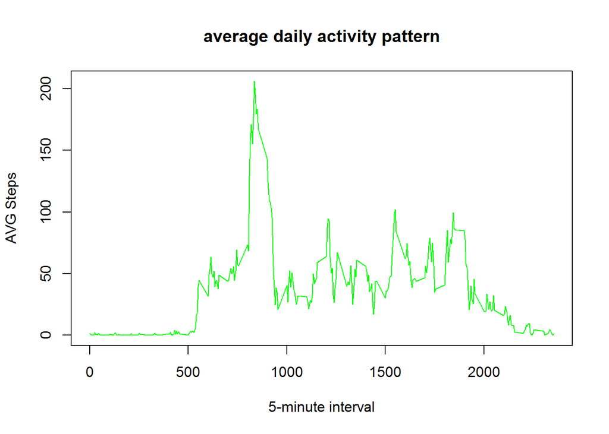

```r
plot(tabla.five$interval,tabla.five$mean, type="l", col="green",
     xlab="5-minute interval", ylab="AVG Steps", main="average daily activity pattern")
```

5.The 5-minute interval that, on average, contains the maximum number of steps

```r
#maximum number of steps
tabla.five[which.max(tabla.five$mean),]
```

```
##     interval     mean
## 104      835 206.1698
```

6.Code to describe and show a strategy for imputing missing data

6.1 Calculate and report the total number of missing values in the dataset (i.e. the total number of rows with NANAs)

```r
print(colSums(is.na(datos)),type="html")
```

```
##    steps     date interval
##     2304        0        0
```

6.2 replace de mising steps data with the mean of steps for its own interval

```r
for(i in 1:nrow(datos)){
  if(is.na(datos[i,1])){
    intervalo <- datos[i,3]
    mean_steps <- round(mean(datos[datos$interval == intervalo,1],na.rm = TRUE))
    datos[i,1] <- mean_steps
  }
}
```

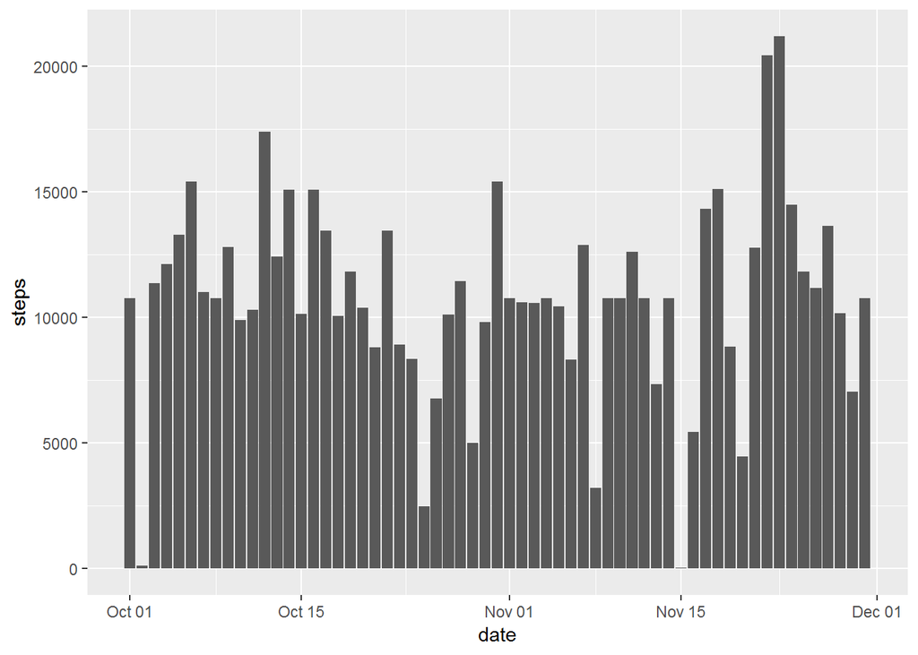

```r
ggplot(datos,aes(x=date,y=steps))+geom_bar(stat='identity')
```

```r
tabla.mean_new <- aggregate(datos[,1], list(datos$date), mean)

colnames(tabla.mean_new) <- c("date","mean")

tabla.median_new <- aggregate(datos[,1], list(datos$date), median)

colnames(tabla.median_new) <- c("date","median")
```

As you can see the missing data was related with missing days. So now the analisys looks complete.

8.1 Create a new factor variable in the dataset with two levels (weekday and weekend) indicating whether a given date is a weekday or weekend day.

```r
datos_last <- datos

weekends <- c("Saturday","Sunday")

datos_last$day_type <- apply(datos_last, 1, FUN = function(x){
  if(weekdays(as.Date(x[2])) %in% weekends){
    "weekend"
  }
  else
    "weekday"
})

datos_last$day_type <- as.factor(datos_last$day_type)

tabla.by_type <- aggregate(datos_last[,1], list(datos_last$interval,datos_last$day_type), sum)

colnames(tabla.by_type) <- c("interval","day_type","steps")
```

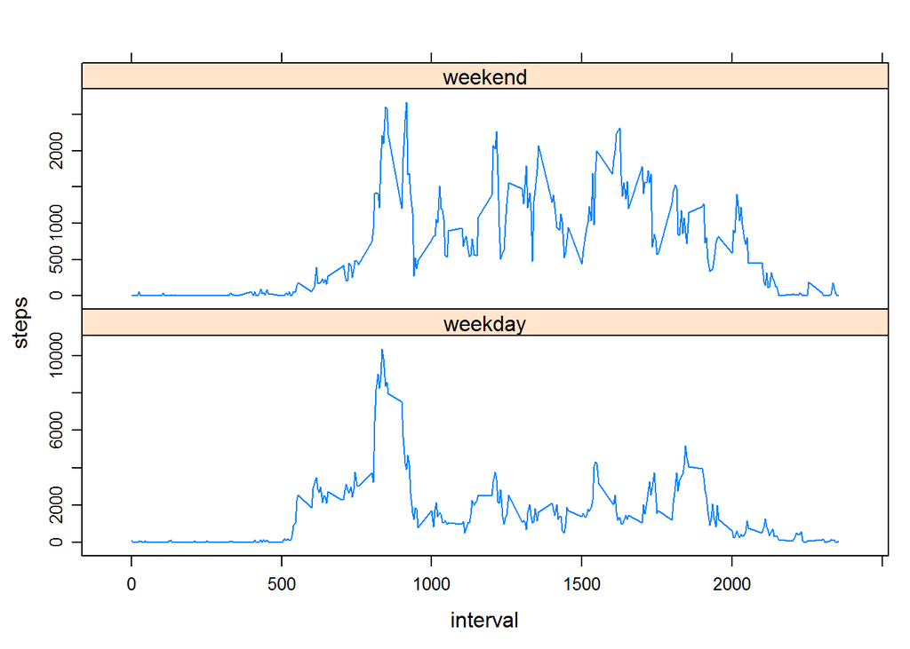

```r
#maximum number of steps
xyplot(steps~interval|day_type,data=tabla.by_type,type="l",scales=list(y=list(relation="free")),layout=c(1,2))
```